# Risk Factor Analysis

## Outcome Variable

**Outcome Variable:** y_rate_haz

## Predictor Variables

**Intervention Variable:** nhh

**Adjustment Set:**

unadjusted

## Stratifying Variables

The analysis was stratified on these variable(s):

- agecat
- studyid
- country

## Data Summary

| agecat | studyid | country | nhh | n_cell | n |
| --- | --- | --- | --- | --- | --- |
| 0-3 months | ki1000108-IRC | INDIA | 3 or less | 53 | 377 |
| 0-3 months | ki1000108-IRC | INDIA | 4-5 | 146 | 377 |
| 0-3 months | ki1000108-IRC | INDIA | 6-7 | 99 | 377 |
| 0-3 months | ki1000108-IRC | INDIA | 8+ | 79 | 377 |
| 0-3 months | ki1017093-NIH-Birth | BANGLADESH | 3 or less | 101 | 566 |
| 0-3 months | ki1017093-NIH-Birth | BANGLADESH | 4-5 | 239 | 566 |
| 0-3 months | ki1017093-NIH-Birth | BANGLADESH | 6-7 | 132 | 566 |
| 0-3 months | ki1017093-NIH-Birth | BANGLADESH | 8+ | 94 | 566 |
| 0-3 months | ki1017093b-PROVIDE | BANGLADESH | 3 or less | 123 | 640 |
| 0-3 months | ki1017093b-PROVIDE | BANGLADESH | 4-5 | 296 | 640 |
| 0-3 months | ki1017093b-PROVIDE | BANGLADESH | 6-7 | 136 | 640 |
| 0-3 months | ki1017093b-PROVIDE | BANGLADESH | 8+ | 85 | 640 |
| 0-3 months | ki1017093c-NIH-Crypto | BANGLADESH | 3 or less | 108 | 721 |
| 0-3 months | ki1017093c-NIH-Crypto | BANGLADESH | 4-5 | 324 | 721 |
| 0-3 months | ki1017093c-NIH-Crypto | BANGLADESH | 6-7 | 169 | 721 |
| 0-3 months | ki1017093c-NIH-Crypto | BANGLADESH | 8+ | 120 | 721 |
| 3-6 months | ki1000108-IRC | INDIA | 3 or less | 57 | 397 |
| 3-6 months | ki1000108-IRC | INDIA | 4-5 | 154 | 397 |
| 3-6 months | ki1000108-IRC | INDIA | 6-7 | 103 | 397 |
| 3-6 months | ki1000108-IRC | INDIA | 8+ | 83 | 397 |
| 3-6 months | ki1017093-NIH-Birth | BANGLADESH | 3 or less | 89 | 523 |
| 3-6 months | ki1017093-NIH-Birth | BANGLADESH | 4-5 | 223 | 523 |
| 3-6 months | ki1017093-NIH-Birth | BANGLADESH | 6-7 | 126 | 523 |
| 3-6 months | ki1017093-NIH-Birth | BANGLADESH | 8+ | 85 | 523 |
| 3-6 months | ki1017093b-PROVIDE | BANGLADESH | 3 or less | 104 | 598 |
| 3-6 months | ki1017093b-PROVIDE | BANGLADESH | 4-5 | 285 | 598 |
| 3-6 months | ki1017093b-PROVIDE | BANGLADESH | 6-7 | 129 | 598 |
| 3-6 months | ki1017093b-PROVIDE | BANGLADESH | 8+ | 80 | 598 |
| 3-6 months | ki1017093c-NIH-Crypto | BANGLADESH | 3 or less | 101 | 695 |
| 3-6 months | ki1017093c-NIH-Crypto | BANGLADESH | 4-5 | 316 | 695 |

[output cut: 138 more lines]

The following strata were considered:

- agecat: 0-3 months, studyid: ki1000108-IRC, country: INDIA
- agecat: 0-3 months, studyid: ki1017093-NIH-Birth, country: BANGLADESH
- agecat: 0-3 months, studyid: ki1017093b-PROVIDE, country: BANGLADESH
- agecat: 0-3 months, studyid: ki1017093c-NIH-Crypto, country: BANGLADESH
- agecat: 12-15 months, studyid: ki1000108-IRC, country: INDIA
- agecat: 12-15 months, studyid: ki1000304b-SAS-FoodSuppl, country: INDIA
- agecat: 12-15 months, studyid: ki1017093-NIH-Birth, country: BANGLADESH
- agecat: 12-15 months, studyid: ki1017093b-PROVIDE, country: BANGLADESH
- agecat: 12-15 months, studyid: ki1017093c-NIH-Crypto, country: BANGLADESH
- agecat: 12-15 months, studyid: ki1148112-LCNI-5, country: MALAWI
- agecat: 15-18 months, studyid: ki1000108-IRC, country: INDIA
- agecat: 15-18 months, studyid: ki1000304b-SAS-FoodSuppl, country: INDIA
- agecat: 15-18 months, studyid: ki1017093-NIH-Birth, country: BANGLADESH
- agecat: 15-18 months, studyid: ki1017093b-PROVIDE, country: BANGLADESH
- agecat: 15-18 months, studyid: ki1017093c-NIH-Crypto, country: BANGLADESH
- agecat: 15-18 months, studyid: ki1148112-LCNI-5, country: MALAWI
- agecat: 18-21 months, studyid: ki1000108-IRC, country: INDIA
- agecat: 18-21 months, studyid: ki1017093-NIH-Birth, country: BANGLADESH
- agecat: 18-21 months, studyid: ki1017093b-PROVIDE, country: BANGLADESH
- agecat: 18-21 months, studyid: ki1017093c-NIH-Crypto, country: BANGLADESH
- agecat: 18-21 months, studyid: ki1148112-LCNI-5, country: MALAWI
- agecat: 21-24 months, studyid: ki1000108-IRC, country: INDIA
- agecat: 21-24 months, studyid: ki1017093-NIH-Birth, country: BANGLADESH
- agecat: 21-24 months, studyid: ki1017093b-PROVIDE, country: BANGLADESH
- agecat: 21-24 months, studyid: ki1017093c-NIH-Crypto, country: BANGLADESH
- agecat: 21-24 months, studyid: ki1148112-LCNI-5, country: MALAWI
- agecat: 3-6 months, studyid: ki1000108-IRC, country: INDIA
- agecat: 3-6 months, studyid: ki1017093-NIH-Birth, country: BANGLADESH
- agecat: 3-6 months, studyid: ki1017093b-PROVIDE, country: BANGLADESH
- agecat: 3-6 months, studyid: ki1017093c-NIH-Crypto, country: BANGLADESH
- agecat: 6-9 months, studyid: ki1000108-IRC, country: INDIA
- agecat: 6-9 months, studyid: ki1000304b-SAS-FoodSuppl, country: INDIA
- agecat: 6-9 months, studyid: ki1017093-NIH-Birth, country: BANGLADESH
- agecat: 6-9 months, studyid: ki1017093b-PROVIDE, country: BANGLADESH
- agecat: 6-9 months, studyid: ki1017093c-NIH-Crypto, country: BANGLADESH
- agecat: 6-9 months, studyid: ki1148112-LCNI-5, country: MALAWI
- agecat: 9-12 months, studyid: ki1000108-IRC, country: INDIA
- agecat: 9-12 months, studyid: ki1000304b-SAS-FoodSuppl, country: INDIA
- agecat: 9-12 months, studyid: ki1017093-NIH-Birth, country: BANGLADESH
- agecat: 9-12 months, studyid: ki1017093b-PROVIDE, country: BANGLADESH
- agecat: 9-12 months, studyid: ki1017093c-NIH-Crypto, country: BANGLADESH
- agecat: 9-12 months, studyid: ki1148112-LCNI-5, country: MALAWI

### Dropped Strata

Some strata were dropped due to rare outcomes:

- agecat: 6-9 months, studyid: ki1000304b-SAS-FoodSuppl, country: INDIA
- agecat: 9-12 months, studyid: ki1000304b-SAS-FoodSuppl, country: INDIA
- agecat: 15-18 months, studyid: ki1000304b-SAS-FoodSuppl, country: INDIA

## Methods Detail

We’re interested in the causal parameters $E[Y_a]$ for all values of $a \in \mathcal{A}$. These parameters represent the mean outcome if, possibly contrary to fact, we intervened to set all units to have $A=a$. Under the randomization and positivity assumptions, these are identified by the statistical parameters $\psi_a=E_W[E_{Y|A,W}(Y|A=a,W)]$. In addition, we’re interested in the mean of $Y$, $E[Y]$ under no intervention (the observed mean). We will estimate these parameters by using SuperLearner to fit the relevant likelihood factors – $E_{Y|A,W}(Y|A=a,W)$ and $p(A=a|W)$, and then updating our likelihood fit using a joint TMLE.

For unadjusted analyses ($W=\{\}$), initial likelihoods were estimated using Lrnr_glm to estimate the simple $E(Y|A)$ and Lrnr_mean to estimate $p(A)$. For adjusted analyses, a small library containing Lrnr_glmnet, Lrnr_xgboost, and Lrnr_mean was used.

Having estimated these parameters, we will then use the delta method to estimate relative risks and attributable risks relative to a prespecified baseline level of $A$.

# Results Detail

## Results Plots

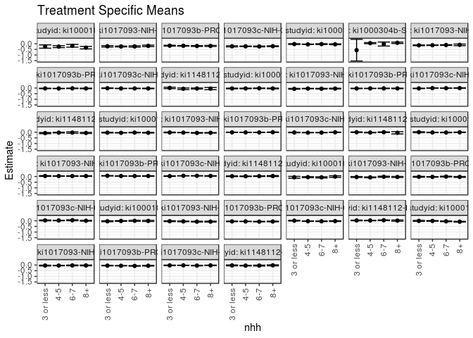

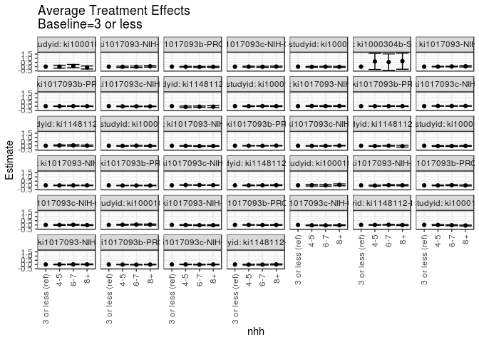

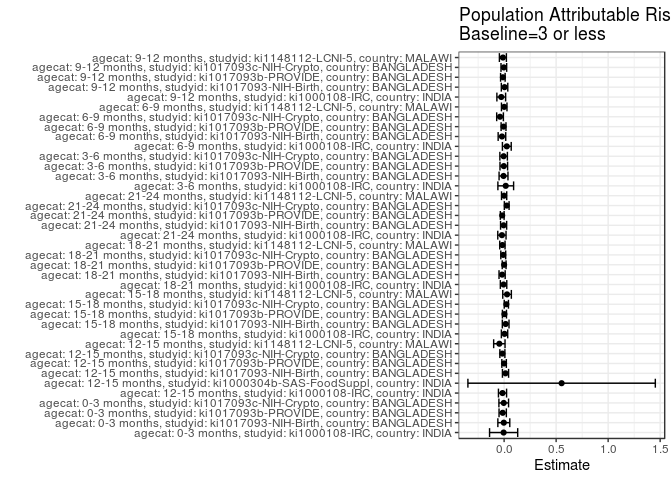

## Results Table

### Parameter: TSM

| agecat | studyid | country | intervention_level | baseline_level | estimate | ci_lower | ci_upper |
| --- | --- | --- | --- | --- | --- | --- | --- |
| 0-3 months | ki1000108-IRC | INDIA | 3 or less | NA | -0.2510737 | -0.3966559 | -0.1054916 |
| 0-3 months | ki1000108-IRC | INDIA | 4-5 | NA | -0.2558025 | -0.3408557 | -0.1707494 |
| 0-3 months | ki1000108-IRC | INDIA | 6-7 | NA | -0.1847141 | -0.3055020 | -0.0639262 |
| 0-3 months | ki1000108-IRC | INDIA | 8+ | NA | -0.3481779 | -0.4568394 | -0.2395163 |
| 0-3 months | ki1017093-NIH-Birth | BANGLADESH | 3 or less | NA | -0.2290780 | -0.2923513 | -0.1658048 |
| 0-3 months | ki1017093-NIH-Birth | BANGLADESH | 4-5 | NA | -0.2445947 | -0.2836927 | -0.2054968 |
| 0-3 months | ki1017093-NIH-Birth | BANGLADESH | 6-7 | NA | -0.2399951 | -0.2989168 | -0.1810733 |
| 0-3 months | ki1017093-NIH-Birth | BANGLADESH | 8+ | NA | -0.1918082 | -0.2567933 | -0.1268232 |
| 0-3 months | ki1017093b-PROVIDE | BANGLADESH | 3 or less | NA | -0.1743320 | -0.2131627 | -0.1355014 |
| 0-3 months | ki1017093b-PROVIDE | BANGLADESH | 4-5 | NA | -0.1851975 | -0.2108350 | -0.1595600 |
| 0-3 months | ki1017093b-PROVIDE | BANGLADESH | 6-7 | NA | -0.2015718 | -0.2399322 | -0.1632115 |
| 0-3 months | ki1017093b-PROVIDE | BANGLADESH | 8+ | NA | -0.1961254 | -0.2428436 | -0.1494073 |
| 0-3 months | ki1017093c-NIH-Crypto | BANGLADESH | 3 or less | NA | -0.2275456 | -0.2789325 | -0.1761587 |
| 0-3 months | ki1017093c-NIH-Crypto | BANGLADESH | 4-5 | NA | -0.2310051 | -0.2557616 | -0.2062486 |
| 0-3 months | ki1017093c-NIH-Crypto | BANGLADESH | 6-7 | NA | -0.2417969 | -0.2784953 | -0.2050985 |
| 0-3 months | ki1017093c-NIH-Crypto | BANGLADESH | 8+ | NA | -0.2204563 | -0.2611758 | -0.1797368 |
| 3-6 months | ki1000108-IRC | INDIA | 3 or less | NA | -0.0675296 | -0.1496225 | 0.0145633 |
| 3-6 months | ki1000108-IRC | INDIA | 4-5 | NA | -0.0567931 | -0.1046158 | -0.0089703 |
| 3-6 months | ki1000108-IRC | INDIA | 6-7 | NA | -0.0727749 | -0.1250467 | -0.0205031 |
| 3-6 months | ki1000108-IRC | INDIA | 8+ | NA | -0.0061435 | -0.0791299 | 0.0668429 |
| 3-6 months | ki1017093-NIH-Birth | BANGLADESH | 3 or less | NA | -0.0451535 | -0.0901732 | -0.0001338 |
| 3-6 months | ki1017093-NIH-Birth | BANGLADESH | 4-5 | NA | -0.0750228 | -0.1099796 | -0.0400660 |
| 3-6 months | ki1017093-NIH-Birth | BANGLADESH | 6-7 | NA | -0.0191869 | -0.0678666 | 0.0294929 |
| 3-6 months | ki1017093-NIH-Birth | BANGLADESH | 8+ | NA | -0.0406444 | -0.0908712 | 0.0095824 |
| 3-6 months | ki1017093b-PROVIDE | BANGLADESH | 3 or less | NA | -0.0238479 | -0.0646103 | 0.0169145 |
| 3-6 months | ki1017093b-PROVIDE | BANGLADESH | 4-5 | NA | -0.0345601 | -0.0563049 | -0.0128153 |
| 3-6 months | ki1017093b-PROVIDE | BANGLADESH | 6-7 | NA | -0.0063105 | -0.0431023 | 0.0304812 |
| 3-6 months | ki1017093b-PROVIDE | BANGLADESH | 8+ | NA | -0.0372462 | -0.0790690 | 0.0045766 |
| 3-6 months | ki1017093c-NIH-Crypto | BANGLADESH | 3 or less | NA | 0.0314652 | -0.0065418 | 0.0694722 |
| 3-6 months | ki1017093c-NIH-Crypto | BANGLADESH | 4-5 | NA | 0.0235468 | -0.0003394 | 0.0474329 |

[output cut: 126 more lines]

### Parameter: E(Y)

| agecat | studyid | country | intervention_level | baseline_level | estimate | ci_lower | ci_upper |
| --- | --- | --- | --- | --- | --- | --- | --- |
| 0-3 months | ki1000108-IRC | INDIA | NA | NA | -0.2558271 | -0.3111464 | -0.2005078 |
| 0-3 months | ki1017093-NIH-Birth | BANGLADESH | NA | NA | -0.2319865 | -0.2585900 | -0.2053830 |
| 0-3 months | ki1017093b-PROVIDE | BANGLADESH | NA | NA | -0.1880402 | -0.2054115 | -0.1706689 |
| 0-3 months | ki1017093c-NIH-Crypto | BANGLADESH | NA | NA | -0.2312607 | -0.2486732 | -0.2138483 |
| 3-6 months | ki1000108-IRC | INDIA | NA | NA | -0.0518918 | -0.0819849 | -0.0217987 |
| 3-6 months | ki1017093-NIH-Birth | BANGLADESH | NA | NA | -0.0509007 | -0.0730097 | -0.0287917 |
| 3-6 months | ki1017093b-PROVIDE | BANGLADESH | NA | NA | -0.0269625 | -0.0428628 | -0.0110622 |
| 3-6 months | ki1017093c-NIH-Crypto | BANGLADESH | NA | NA | 0.0267740 | 0.0099602 | 0.0435879 |
| 6-9 months | ki1000108-IRC | INDIA | NA | NA | -0.0162677 | -0.0378604 | 0.0053250 |
| 6-9 months | ki1017093-NIH-Birth | BANGLADESH | NA | NA | -0.0595548 | -0.0774135 | -0.0416961 |
| 6-9 months | ki1017093b-PROVIDE | BANGLADESH | NA | NA | -0.0614264 | -0.0722690 | -0.0505838 |
| 6-9 months | ki1017093c-NIH-Crypto | BANGLADESH | NA | NA | -0.0313638 | -0.0441155 | -0.0186120 |
| 6-9 months | ki1148112-LCNI-5 | MALAWI | NA | NA | 0.0279334 | 0.0120046 | 0.0438622 |
| 9-12 months | ki1000108-IRC | INDIA | NA | NA | -0.0361313 | -0.0530672 | -0.0191954 |
| 9-12 months | ki1017093-NIH-Birth | BANGLADESH | NA | NA | -0.0424748 | -0.0569242 | -0.0280255 |
| 9-12 months | ki1017093b-PROVIDE | BANGLADESH | NA | NA | -0.0630470 | -0.0740183 | -0.0520757 |
| 9-12 months | ki1017093c-NIH-Crypto | BANGLADESH | NA | NA | -0.0342995 | -0.0452397 | -0.0233593 |
| 9-12 months | ki1148112-LCNI-5 | MALAWI | NA | NA | -0.0433141 | -0.0626948 | -0.0239333 |
| 12-15 months | ki1000108-IRC | INDIA | NA | NA | -0.0454519 | -0.0622041 | -0.0286997 |
| 12-15 months | ki1000304b-SAS-FoodSuppl | INDIA | NA | NA | -0.0180759 | -0.1219384 | 0.0857866 |
| 12-15 months | ki1017093-NIH-Birth | BANGLADESH | NA | NA | -0.1259588 | -0.1428870 | -0.1090306 |
| 12-15 months | ki1017093b-PROVIDE | BANGLADESH | NA | NA | -0.0409107 | -0.0510053 | -0.0308161 |
| 12-15 months | ki1017093c-NIH-Crypto | BANGLADESH | NA | NA | -0.0383313 | -0.0478154 | -0.0288473 |
| 12-15 months | ki1148112-LCNI-5 | MALAWI | NA | NA | -0.0403575 | -0.0774359 | -0.0032790 |
| 15-18 months | ki1000108-IRC | INDIA | NA | NA | -0.0385167 | -0.0531981 | -0.0238352 |
| 15-18 months | ki1017093-NIH-Birth | BANGLADESH | NA | NA | -0.0576906 | -0.0723785 | -0.0430027 |
| 15-18 months | ki1017093b-PROVIDE | BANGLADESH | NA | NA | -0.0376437 | -0.0463882 | -0.0288992 |
| 15-18 months | ki1017093c-NIH-Crypto | BANGLADESH | NA | NA | -0.0169074 | -0.0252557 | -0.0085590 |
| 15-18 months | ki1148112-LCNI-5 | MALAWI | NA | NA | -0.0464023 | -0.0722064 | -0.0205982 |
| 18-21 months | ki1000108-IRC | INDIA | NA | NA | -0.0400816 | -0.0533440 | -0.0268193 |
| 18-21 months | ki1017093-NIH-Birth | BANGLADESH | NA | NA | -0.0383890 | -0.0508204 | -0.0259576 |
| 18-21 months | ki1017093b-PROVIDE | BANGLADESH | NA | NA | -0.0109399 | -0.0190984 | -0.0027814 |
| 18-21 months | ki1017093c-NIH-Crypto | BANGLADESH | NA | NA | -0.0279687 | -0.0360019 | -0.0199355 |
| 18-21 months | ki1148112-LCNI-5 | MALAWI | NA | NA | -0.0147327 | -0.0309734 | 0.0015080 |
| 21-24 months | ki1000108-IRC | INDIA | NA | NA | -0.0139081 | -0.0274784 | -0.0003379 |
| 21-24 months | ki1017093-NIH-Birth | BANGLADESH | NA | NA | 0.0406915 | 0.0289394 | 0.0524435 |
| 21-24 months | ki1017093b-PROVIDE | BANGLADESH | NA | NA | 0.0462342 | 0.0375872 | 0.0548812 |
| 21-24 months | ki1017093c-NIH-Crypto | BANGLADESH | NA | NA | 0.0587621 | 0.0505315 | 0.0669927 |
| 21-24 months | ki1148112-LCNI-5 | MALAWI | NA | NA | 0.0258428 | 0.0105053 | 0.0411803 |

### Parameter: ATE

| agecat | studyid | country | intervention_level | baseline_level | estimate | ci_lower | ci_upper |
| --- | --- | --- | --- | --- | --- | --- | --- |
| 0-3 months | ki1000108-IRC | INDIA | 3 or less | 3 or less | 0.0000000 | 0.0000000 | 0.0000000 |
| 0-3 months | ki1000108-IRC | INDIA | 4-5 | 3 or less | -0.0047288 | -0.1733354 | 0.1638778 |
| 0-3 months | ki1000108-IRC | INDIA | 6-7 | 3 or less | 0.0663596 | -0.1228066 | 0.2555259 |
| 0-3 months | ki1000108-IRC | INDIA | 8+ | 3 or less | -0.0971041 | -0.2787673 | 0.0845590 |
| 0-3 months | ki1017093-NIH-Birth | BANGLADESH | 3 or less | 3 or less | 0.0000000 | 0.0000000 | 0.0000000 |
| 0-3 months | ki1017093-NIH-Birth | BANGLADESH | 4-5 | 3 or less | -0.0155167 | -0.0898951 | 0.0588618 |
| 0-3 months | ki1017093-NIH-Birth | BANGLADESH | 6-7 | 3 or less | -0.0109171 | -0.0973767 | 0.0755426 |
| 0-3 months | ki1017093-NIH-Birth | BANGLADESH | 8+ | 3 or less | 0.0372698 | -0.0534306 | 0.1279702 |
| 0-3 months | ki1017093b-PROVIDE | BANGLADESH | 3 or less | 3 or less | 0.0000000 | 0.0000000 | 0.0000000 |
| 0-3 months | ki1017093b-PROVIDE | BANGLADESH | 4-5 | 3 or less | -0.0108654 | -0.0573961 | 0.0356652 |
| 0-3 months | ki1017093b-PROVIDE | BANGLADESH | 6-7 | 3 or less | -0.0272398 | -0.0818231 | 0.0273435 |
| 0-3 months | ki1017093b-PROVIDE | BANGLADESH | 8+ | 3 or less | -0.0217934 | -0.0825421 | 0.0389553 |
| 0-3 months | ki1017093c-NIH-Crypto | BANGLADESH | 3 or less | 3 or less | 0.0000000 | 0.0000000 | 0.0000000 |
| 0-3 months | ki1017093c-NIH-Crypto | BANGLADESH | 4-5 | 3 or less | -0.0034595 | -0.0604989 | 0.0535800 |
| 0-3 months | ki1017093c-NIH-Crypto | BANGLADESH | 6-7 | 3 or less | -0.0142513 | -0.0773971 | 0.0488945 |
| 0-3 months | ki1017093c-NIH-Crypto | BANGLADESH | 8+ | 3 or less | 0.0070893 | -0.0584751 | 0.0726537 |
| 3-6 months | ki1000108-IRC | INDIA | 3 or less | 3 or less | 0.0000000 | 0.0000000 | 0.0000000 |
| 3-6 months | ki1000108-IRC | INDIA | 4-5 | 3 or less | 0.0107365 | -0.0842701 | 0.1057431 |
| 3-6 months | ki1000108-IRC | INDIA | 6-7 | 3 or less | -0.0052453 | -0.1025674 | 0.0920767 |
| 3-6 months | ki1000108-IRC | INDIA | 8+ | 3 or less | 0.0613861 | -0.0484604 | 0.1712326 |
| 3-6 months | ki1017093-NIH-Birth | BANGLADESH | 3 or less | 3 or less | 0.0000000 | 0.0000000 | 0.0000000 |
| 3-6 months | ki1017093-NIH-Birth | BANGLADESH | 4-5 | 3 or less | -0.0298693 | -0.0868671 | 0.0271285 |
| 3-6 months | ki1017093-NIH-Birth | BANGLADESH | 6-7 | 3 or less | 0.0259667 | -0.0403393 | 0.0922727 |
| 3-6 months | ki1017093-NIH-Birth | BANGLADESH | 8+ | 3 or less | 0.0045091 | -0.0629409 | 0.0719591 |
| 3-6 months | ki1017093b-PROVIDE | BANGLADESH | 3 or less | 3 or less | 0.0000000 | 0.0000000 | 0.0000000 |
| 3-6 months | ki1017093b-PROVIDE | BANGLADESH | 4-5 | 3 or less | -0.0107122 | -0.0569119 | 0.0354875 |
| 3-6 months | ki1017093b-PROVIDE | BANGLADESH | 6-7 | 3 or less | 0.0175374 | -0.0373735 | 0.0724483 |
| 3-6 months | ki1017093b-PROVIDE | BANGLADESH | 8+ | 3 or less | -0.0133983 | -0.0717997 | 0.0450030 |
| 3-6 months | ki1017093c-NIH-Crypto | BANGLADESH | 3 or less | 3 or less | 0.0000000 | 0.0000000 | 0.0000000 |
| 3-6 months | ki1017093c-NIH-Crypto | BANGLADESH | 4-5 | 3 or less | -0.0079184 | -0.0528080 | 0.0369712 |

[output cut: 126 more lines]

### Parameter: PAR

| agecat | studyid | country | intervention_level | baseline_level | estimate | ci_lower | ci_upper |
| --- | --- | --- | --- | --- | --- | --- | --- |
| 0-3 months | ki1000108-IRC | INDIA | 3 or less | NA | -0.0047534 | -0.1400135 | 0.1305067 |
| 0-3 months | ki1017093-NIH-Birth | BANGLADESH | 3 or less | NA | -0.0029084 | -0.0602010 | 0.0543841 |
| 0-3 months | ki1017093b-PROVIDE | BANGLADESH | 3 or less | NA | -0.0137082 | -0.0487797 | 0.0213634 |
| 0-3 months | ki1017093c-NIH-Crypto | BANGLADESH | 3 or less | NA | -0.0037152 | -0.0501126 | 0.0426823 |
| 3-6 months | ki1000108-IRC | INDIA | 3 or less | NA | 0.0156378 | -0.0599244 | 0.0911999 |
| 3-6 months | ki1017093-NIH-Birth | BANGLADESH | 3 or less | NA | -0.0057472 | -0.0484763 | 0.0369820 |
| 3-6 months | ki1017093b-PROVIDE | BANGLADESH | 3 or less | NA | -0.0031146 | -0.0396722 | 0.0334430 |
| 3-6 months | ki1017093c-NIH-Crypto | BANGLADESH | 3 or less | NA | -0.0046911 | -0.0408489 | 0.0314667 |
| 6-9 months | ki1000108-IRC | INDIA | 3 or less | NA | 0.0258876 | -0.0164664 | 0.0682416 |
| 6-9 months | ki1017093-NIH-Birth | BANGLADESH | 3 or less | NA | -0.0209796 | -0.0574065 | 0.0154472 |
| 6-9 months | ki1017093b-PROVIDE | BANGLADESH | 3 or less | NA | -0.0055667 | -0.0289776 | 0.0178443 |
| 6-9 months | ki1017093c-NIH-Crypto | BANGLADESH | 3 or less | NA | -0.0394064 | -0.0713771 | -0.0074357 |
| 6-9 months | ki1148112-LCNI-5 | MALAWI | 3 or less | NA | 0.0009103 | -0.0255949 | 0.0274154 |
| 9-12 months | ki1000108-IRC | INDIA | 3 or less | NA | -0.0274766 | -0.0695591 | 0.0146058 |
| 9-12 months | ki1017093-NIH-Birth | BANGLADESH | 3 or less | NA | 0.0041948 | -0.0268377 | 0.0352274 |
| 9-12 months | ki1017093b-PROVIDE | BANGLADESH | 3 or less | NA | -0.0120510 | -0.0339640 | 0.0098619 |
| 9-12 months | ki1017093c-NIH-Crypto | BANGLADESH | 3 or less | NA | -0.0027638 | -0.0299454 | 0.0244178 |
| 9-12 months | ki1148112-LCNI-5 | MALAWI | 3 or less | NA | -0.0117906 | -0.0454035 | 0.0218223 |
| 12-15 months | ki1000108-IRC | INDIA | 3 or less | NA | -0.0153838 | -0.0544518 | 0.0236842 |
| 12-15 months | ki1000304b-SAS-FoodSuppl | INDIA | 3 or less | NA | 0.5526763 | -0.3481036 | 1.4534562 |
| 12-15 months | ki1017093-NIH-Birth | BANGLADESH | 3 or less | NA | 0.0133338 | -0.0162403 | 0.0429080 |
| 12-15 months | ki1017093b-PROVIDE | BANGLADESH | 3 or less | NA | -0.0002873 | -0.0219777 | 0.0214031 |
| 12-15 months | ki1017093c-NIH-Crypto | BANGLADESH | 3 or less | NA | -0.0167478 | -0.0409563 | 0.0074606 |
| 12-15 months | ki1148112-LCNI-5 | MALAWI | 3 or less | NA | -0.0458204 | -0.1005289 | 0.0088882 |
| 15-18 months | ki1000108-IRC | INDIA | 3 or less | NA | 0.0039704 | -0.0265142 | 0.0344550 |
| 15-18 months | ki1017093-NIH-Birth | BANGLADESH | 3 or less | NA | 0.0148444 | -0.0173627 | 0.0470514 |
| 15-18 months | ki1017093b-PROVIDE | BANGLADESH | 3 or less | NA | 0.0030770 | -0.0164528 | 0.0226067 |
| 15-18 months | ki1017093c-NIH-Crypto | BANGLADESH | 3 or less | NA | 0.0215297 | 0.0013075 | 0.0417518 |
| 15-18 months | ki1148112-LCNI-5 | MALAWI | 3 or less | NA | 0.0281119 | -0.0132476 | 0.0694715 |
| 18-21 months | ki1000108-IRC | INDIA | 3 or less | NA | -0.0053746 | -0.0362350 | 0.0254859 |
| 18-21 months | ki1017093-NIH-Birth | BANGLADESH | 3 or less | NA | -0.0193838 | -0.0489840 | 0.0102165 |
| 18-21 months | ki1017093b-PROVIDE | BANGLADESH | 3 or less | NA | 0.0001368 | -0.0182346 | 0.0185082 |
| 18-21 months | ki1017093c-NIH-Crypto | BANGLADESH | 3 or less | NA | -0.0084081 | -0.0318216 | 0.0150053 |
| 18-21 months | ki1148112-LCNI-5 | MALAWI | 3 or less | NA | -0.0165406 | -0.0420945 | 0.0090133 |
| 21-24 months | ki1000108-IRC | INDIA | 3 or less | NA | -0.0212916 | -0.0609874 | 0.0184042 |
| 21-24 months | ki1017093-NIH-Birth | BANGLADESH | 3 or less | NA | -0.0049737 | -0.0342135 | 0.0242660 |
| 21-24 months | ki1017093b-PROVIDE | BANGLADESH | 3 or less | NA | -0.0182601 | -0.0364653 | -0.0000550 |
| 21-24 months | ki1017093c-NIH-Crypto | BANGLADESH | 3 or less | NA | 0.0250406 | 0.0023877 | 0.0476935 |
| 21-24 months | ki1148112-LCNI-5 | MALAWI | 3 or less | NA | -0.0000796 | -0.0251283 | 0.0249691 |